# Progress Memo 1

Final Project  
Data Science 2 with R (STAT 301-2)

Author

Reed Malcolm

Published

February 7, 2025

**Github Repo Link**

[Reed’s Final Project GitHub Repo](https://github.com/stat301-2-2025-winter/final-project-2-malcor21.git)

## Prediction problem

This final project will investigate the predictive power of social characteristics data on voting habits. Specifically, I will construct a regression problem to examine how county-level demographic information might be used to forecast Democratic Party presidential voteshare in the 2020 US election.

I am pursuing this final project topic on account of my personal interest in elections and social science broadly. It is certainly important for campaigns to estimate their support based on demographic data rather than polling alone; political consultants likely employ a variety of predictive modeling methods to advise their clients. However, I am approaching this topic from the standpoint of a hobbyist observer—I hope that this project will present an enjoyable opportunity to apply my data science skills to a subset of social science data with which I am already somewhat familiar. And while the particular workflows developed during the project are not necessarily applicable to other elections on account of changing demographics and political trends, I hope that the lessons I learn here regarding feature engineering with survey data will prove useful in my future personal and professional endeavors.

## Data source

This final project will utilize the “US Election Dataset” constructed by Kaggle user Essarabi.[^1] The .csv file includes information on voting habits (raw counts and shares) as well as demographic characteristics, such as racial makeup, education, income, and occupation, at the county level. According to Essarabi, data is sourced from the 2020 US Decennial Census, the American Community Survey’s 2022 5-year estimates, and the “US Election 2020” Kaggle dataset.[^2]

<sup>1</sup> Essarabi (2024), [US Election Dataset](https://www.kaggle.com/datasets/essarabi/ultimate-us-election-dataset)

<sup>2</sup> Fontes, R (n.d.), [US Election 2020](https://www.kaggle.com/datasets/unanimad/us-election-2020)

## Data quality check

Table 1: Overview of US Election Dataset

| Version | Observations | Columns | Numeric variables | Character variables |
| --- | --- | --- | --- | --- |
| As-imported | 3143 | 35 | 25 | 10 |
| Tidy | 3143 | 28 | 27 | 1 |

The “US Election Dataset” .csv file imports with 3143 rows and 35 columns. Though it falls on the lower end of acceptable observation counts, the dataset is naturally limited by the number of counties in the United States.

25 of the file’s variables, largely demographic statistics, are numeric. Five of those numeric columns will almost certainly be excluded in future stages of this project: three consist of raw vote counts, which are redundant, and two provide the vote share for Republican and Other presidential candidates. The latter columns, being unobservable prior to the 2020 US election, do not constitute useful predictors.

The “US Election Dataset” also contains 10 character variables. Two of these are duplicate county or state identifiers that will be discarded. An additional seven character variables in the dataset are actually miscoded numeric features that correspond to education levels. At least some of those columns will be converted to numeric proportions during preprocessing.

Finally, the dataset has practically no missingness: every column except `Median income (dollars)`, which lacks just a single observation, has a 100% complete rate. “US Election Dataset” is also tidy upon import, with one row corresponding to a single county-observation, save for the character variable miscoding mentioned previously.

Table 1 above provides an overview of the structure of the “US Election Dataset”. Values are provided both for the file as imported and for an anticipated tidied version that will be developed prior to the modeling process.

## Target variable analysis

Table 2: Statistical overview of Democratic presidential vote share, 2020

| Mean | SD | 0 pct | 25 pct | 50 pct | 75 pct | 100 pct |
| --- | --- | --- | --- | --- | --- | --- |
| 33.4 | 16 | 3.09 | 21 | 30 | 42.6 | 95.8 |

Table 2 displays summary statistics for `2020 Democrat vote %`, the county-level vote share for the Democratic presidential candidate in the 2020 US election, as obtained from the `skimr` package’s `skim_without_charts` function. The mean of the Democratic voteshare variable slightly exceeds its median, indicating that the prediction problem’s target variable is somewhat right-skewed.

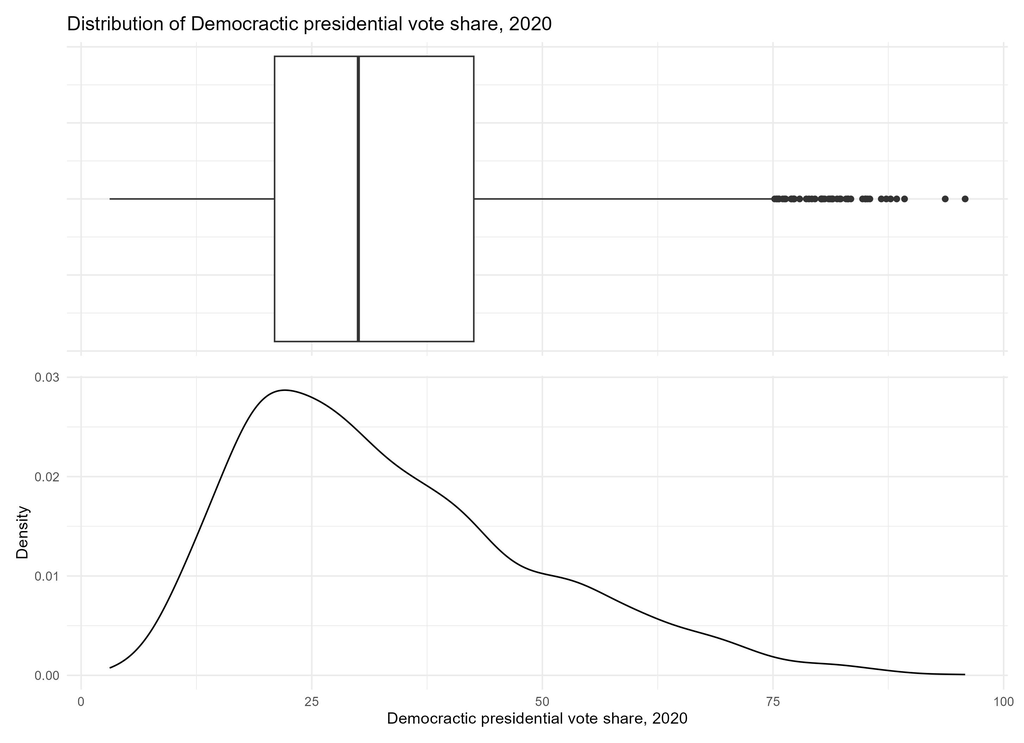

Figure 1: Distribution of Democratic presidential vote share at the county level, 2020

## Misc

I would be interested in incorporating 2024 presidential election data into this final project if time permits. Since county-level demographics likely experienced only limited change between the 2020 and 2024 US elections, I might consider adding a 2024 Democratic presidential voteshare column to the dataset and comparing the predictive accuracy of project workflows between the two cases (i.e., exploring if the most accurate workflow for predicting 2020 voteshare holds up in 2024). Please let me know if you have any thoughts or tips on this idea!